# Regression model VI : transformation / generalization

related chapter : 9 & 10

# 1 Transformation

One may need to transform the response and/or predictors to make sure that

1. the error satisfies certain conditions
2. the model obeys a desired form (such as linear models)

# 2 Broken stick regression / change point

Sometimes we have reason to believe that different linear regression models apply in different regions of the data.

```r
library(faraway)
```

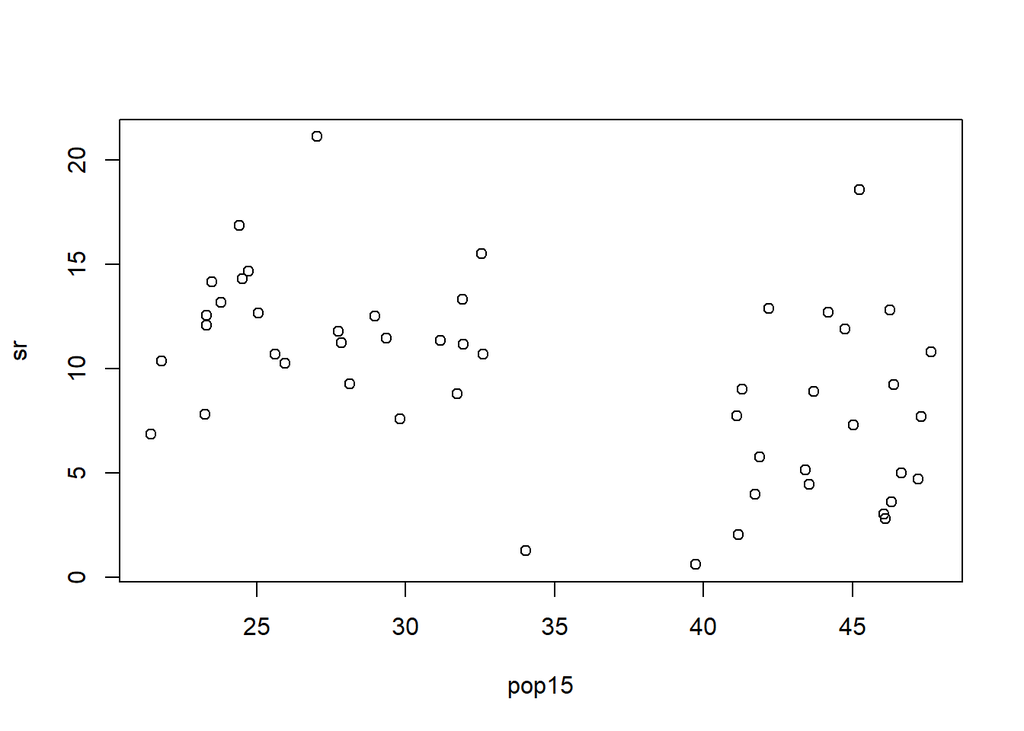

```r
data(savings, package="faraway")
plot(sr~pop15,data=savings)
```

we observe that there were two groups in the data and we might want to fit a different model to the two parts.

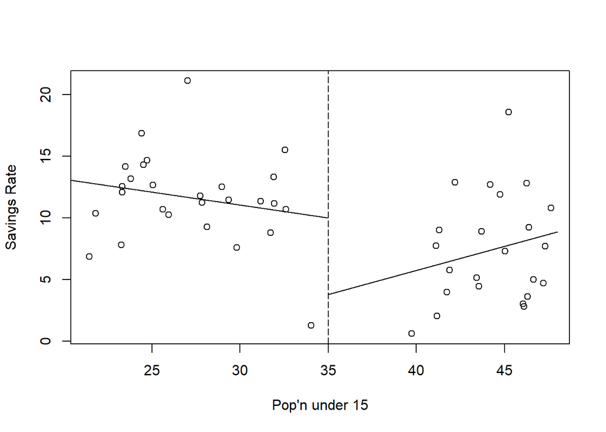

```r
lmod1 <- lm(sr ~ pop15, savings, subset=(pop15 < 35))
lmod2 <- lm(sr ~ pop15, savings, subset=(pop15 > 35))
plot(sr ~ pop15,savings,xlab="Pop'n under 15",  ylab="Savings Rate")
abline(v=35,lty=5)
segments(20,lmod1$coef[1]+lmod1$coef[2]*20,35,  lmod1$coef[1]+lmod1$coef[2]*35)
segments(48,lmod2$coef[1]+lmod2$coef[2]*48,35,  lmod2$coef[1]+lmod2$coef[2]*35)
```

This has a disadvantage that the two lines do not meet at 35. One can consider a continuous model.

$$y=\beta_0 + \beta_1 B_1(x) + \beta_2 B_2(x) + \epsilon$$

where $B_1(x)=(c-x)I(c-x>0)$ and $B_2(x)=-(c-x)I(c-x<0)$. Note that this model has only three parameters.

p.s.Here $B_1, B_2$ form a first-order spline basis with a knotpoint at $c$.

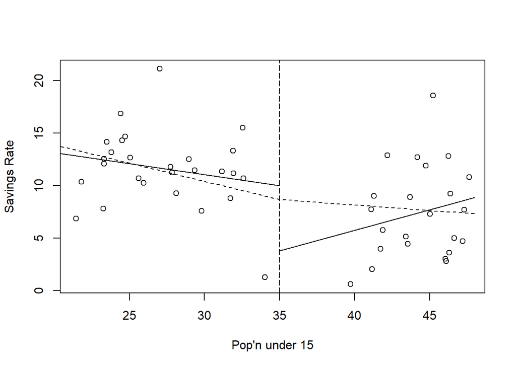

```r
lhs <- function(x) ifelse(x < 35,35-x,0)
rhs <- function(x) ifelse(x < 35,0,x-35)
lmod <- lm(sr ~ lhs(pop15) + rhs(pop15), savings)
x <- seq(20,48,by=1)
py <- lmod$coef[1] + lmod$coef[2]*lhs(x) + lmod$coef[3]*rhs(x)
plot(sr ~ pop15,savings,xlab="Pop'n under 15",  ylab="Savings Rate")
abline(v=35,lty=5)
segments(20,lmod1$coef[1]+lmod1$coef[2]*20,35,  lmod1$coef[1]+lmod1$coef[2]*35)
segments(48,lmod2$coef[1]+lmod2$coef[2]*48,35,  lmod2$coef[1]+lmod2$coef[2]*35)
lines(x,py,lty=2)
```

We can have more than one knotpoint simply by defining more basis functions with different knotpoints.

# 3 Polynomials

We may consider the model as

$$y=\beta_0 + \beta_1x + \beta_2 x^2 + \cdots + \beta_d x^d + \epsilon$$
There are two common ways to choose d. We can keep adding terms until the added term is not statistically significant. Alternatively, we can start with a large d and eliminate non-statistically significant terms starting with the highest order term.

```r
summary(lm(sr ~ ddpi,savings))
```

```
##
## Call:
## lm(formula = sr ~ ddpi, data = savings)
##
## Residuals:
##     Min      1Q  Median      3Q     Max
## -8.5535 -3.7349  0.9835  2.7720  9.3104
##
## Coefficients:
##             Estimate Std. Error t value Pr(>|t|)
## (Intercept)   7.8830     1.0110   7.797 4.46e-10 ***
## ddpi          0.4758     0.2146   2.217   0.0314 *
## ---
## Signif. codes:  0 '***' 0.001 '**' 0.01 '*' 0.05 '.' 0.1 ' ' 1
##
## Residual standard error: 4.311 on 48 degrees of freedom
## Multiple R-squared:  0.0929, Adjusted R-squared:  0.074
## F-statistic: 4.916 on 1 and 48 DF,  p-value: 0.03139
```

```r
summary(lm(sr ~ ddpi+I(ddpi^2),savings))
```

```
##
## Call:
## lm(formula = sr ~ ddpi + I(ddpi^2), data = savings)
##
## Residuals:
##     Min      1Q  Median      3Q     Max
## -8.5601 -2.5612  0.5546  2.5735  7.8080
##
## Coefficients:
##             Estimate Std. Error t value Pr(>|t|)
## (Intercept)  5.13038    1.43472   3.576 0.000821 ***
## ddpi         1.75752    0.53772   3.268 0.002026 **
## I(ddpi^2)   -0.09299    0.03612  -2.574 0.013262 *
## ---
## Signif. codes:  0 '***' 0.001 '**' 0.01 '*' 0.05 '.' 0.1 ' ' 1
##
## Residual standard error: 4.079 on 47 degrees of freedom
## Multiple R-squared:  0.205,  Adjusted R-squared:  0.1711
## F-statistic: 6.059 on 2 and 47 DF,  p-value: 0.004559
```

```r
summary(lm(sr ~ ddpi+I(ddpi^2)+I(ddpi^3),savings))
```

```
##
## Call:
## lm(formula = sr ~ ddpi + I(ddpi^2) + I(ddpi^3), data = savings)
##
## Residuals:
##     Min      1Q  Median      3Q     Max
## -8.5571 -2.5575  0.5616  2.5756  7.7984
##
## Coefficients:
##               Estimate Std. Error t value Pr(>|t|)
## (Intercept)  5.145e+00  2.199e+00   2.340   0.0237 *
## ddpi         1.746e+00  1.380e+00   1.265   0.2123
## I(ddpi^2)   -9.097e-02  2.256e-01  -0.403   0.6886
## I(ddpi^3)   -8.497e-05  9.374e-03  -0.009   0.9928
## ---
## Signif. codes:  0 '***' 0.001 '**' 0.01 '*' 0.05 '.' 0.1 ' ' 1
##
## Residual standard error: 4.123 on 46 degrees of freedom
## Multiple R-squared:  0.205,  Adjusted R-squared:  0.1531
## F-statistic: 3.953 on 3 and 46 DF,  p-value: 0.01369
```

You have to refit the model each time a term is removed which is inconvenient and for large d there can be a problem with numerical stability. Orthogonal polynomials get around this problem by defining:

$$\begin{eqnarray}
z_1 & = & a_1 + b_1 x \\
z_2 & = & a_2 + b_2 x + c_2 x^2 \\
z_3 & = & a_3 + b_3 x + c_3 x^2 + d_3 x^3
\end{eqnarray}$$

such that $z_i^\top z_j=0,~i\neq j$. We only need to fit once.

```r
lmod <- lm(sr ~ poly(ddpi,4),savings)
sumary(lmod)
```

```
##                  Estimate Std. Error t value Pr(>|t|)
## (Intercept)      9.671000   0.584602 16.5429  < 2e-16
## poly(ddpi, 4)1   9.558993   4.133760  2.3124  0.02539
## poly(ddpi, 4)2 -10.499876   4.133760 -2.5400  0.01461
## poly(ddpi, 4)3  -0.037374   4.133760 -0.0090  0.99283
## poly(ddpi, 4)4   3.611968   4.133760  0.8738  0.38688
##
## n = 50, p = 5, Residual SE = 4.13376, R-Squared = 0.22
```

# 4 Splines

Polynomials have the advantage of smoothness, but the disadvantage is that each data point affects the fit globally. In contrast, the broken stick regression method localizes the influence of each data point to its particular segment which is good, but we do not have the same smoothness as with the polynomials. There is a way we can combine the beneficial aspects of both these methods—smoothness and local influence by using $B$-spline basis functions.

> Example

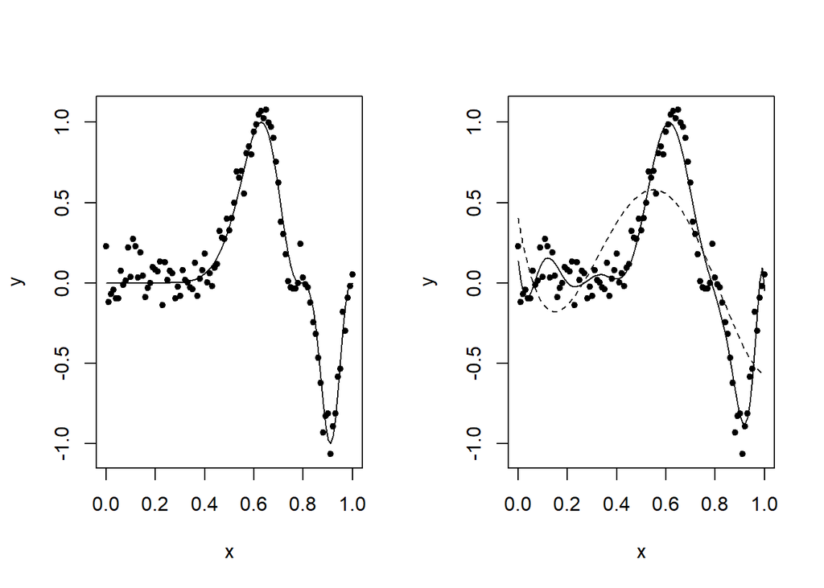

```r
set.seed(7)
funky <- function(x) sin(2*pi*x^3)^3
x <- seq(0,1,by=0.01)
y <- funky(x) + 0.1*rnorm(101)
par(mfrow=c(1,2))
matplot(x,cbind(y,funky(x)),type="pl",ylab="y",pch=20, lty=1, col=1)
g4 <- lm(y ~ poly(x,4))
g12 <- lm(y ~ poly(x,12))
matplot(x,cbind(y,g4$fit,g12$fit),type="pll",  ylab="y",lty=c(1,2), pch=20, col=1)
```

We see that order 4 is a clear underfit; order 12 is much better although the fit is too wiggly in the first section and misses the point of inflection around $x = 0.8$.

We may define a cubic $B$-spline basis on the interval $[a,b]$ by the following requirements on the interior basis functions with knotpoints at $t_1,\ldots, t_k$:

1. A given basis function is nonzero on an interval defined by four successive knots and zero elsewhere. This property ensures the local influence property.
2. The basis function is a cubic polynomial for each subinterval between successive knots.
3. The basis function is continuous and is also continuous in its first and second derivatives at each knotpoint. This property ensures the smoothness of the fit.
4. The basis function integrates to one over its support.

```r
require(splines)
```

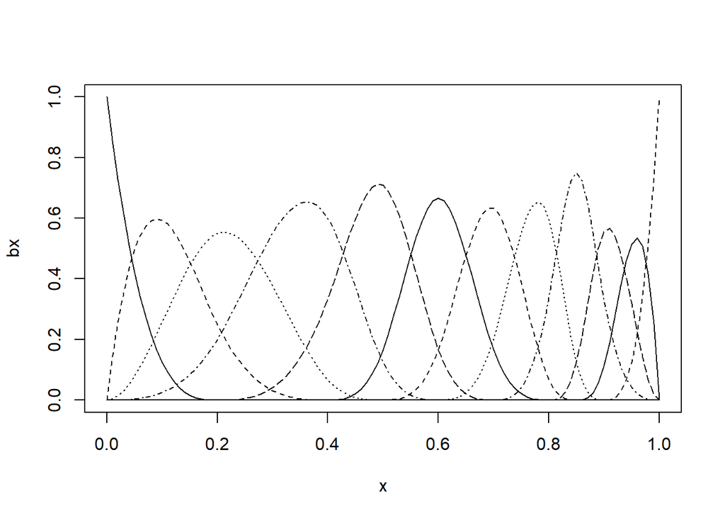

```r
knots <- c(0,0,0,0,0.2,0.4,0.5,0.6,0.7,0.8,0.85,0.9,1,1,1,1) # 12 basis functions
bx <- splineDesign(knots,x)
lmodb <- lm(y ~ bx -1)
matplot(x, bx, type="l", col=1)  # cubic spline basis function
```

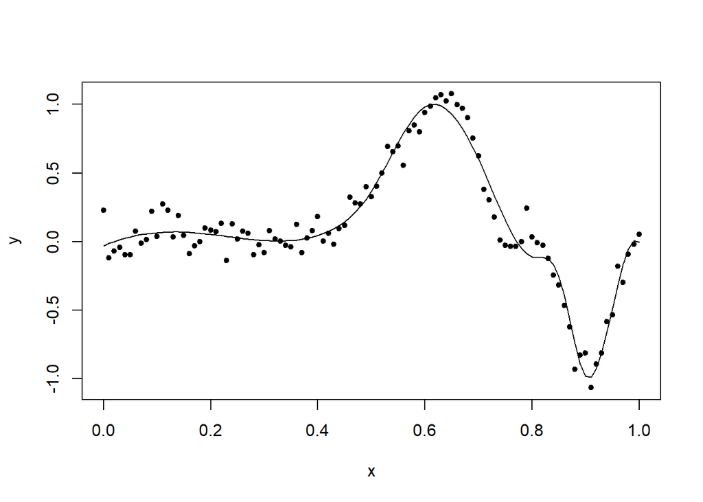

```r
matplot(x, cbind(y,lmodb$fit), type="pl", ylab="y", pch=20,lty=1, col=1)  # cubic spline fit
```

Note : the number of basis function = total number of knots - degree - 1

One alternative is smoothing splines. We choose $\hat f$ to minimize a modified least squares criterion:

$$n^{-1}\sum_{i=1}^n [Y_i - f(x_i)]^2 + \lambda \int (f''(x))^2 dx$$

where $\lambda$ is a roughness penalty which controls the amount of smoothing.

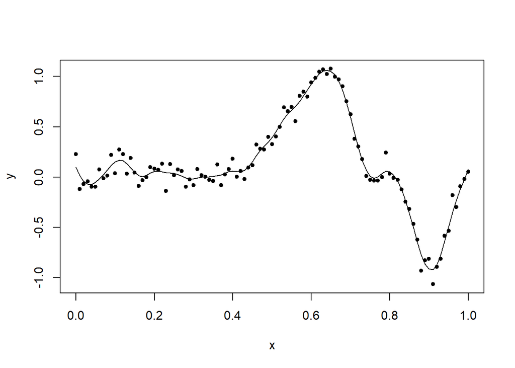

```r
ssf <- smooth.spline(x,y)
matplot(x,cbind(y,ssf$y),type="pl",ylab="y", lty=1, pch=20, col=1)
```

# 5 Kernel regression

In the above, we did not assume any particular form on the model structure. The number of parameters to be estimated is not finite. We call this type of regression ``nonparametric regression“. Here we introduce another type of regression estimation strategy, which is based on the kernel function.

We start from the simplest form, Nadaraya-Watson kernel regression. Assume that the model form is defined as:

$$Y = f(X) + \epsilon$$

where proper assumptions on $\epsilon$ are made. Then, $f$ can be estimated as

$$\hat f_h(x) = \frac{\sum_{i=1}^n K_h (X_i - x) Y_i}{\sum_{i=1}^n K_h (X_i - x)}$$
where $K_h$ is a kernel function with bandwidth $h>0 and $K_h(t) = (1/h)K(t/h)$. Often $K$ is defined as a symmetric probability density function.

```r
library(np)
# local constant estimator, gaussian kernel & automatic selection for h
nfit1 <- npreg(y~x,regtype="lc",ckertype="gaussian")
```

```
##
Multistart 1 of 1 |
Multistart 1 of 1 |
Multistart 1 of 1 |
Multistart 1 of 1 /
Multistart 1 of 1 |
Multistart 1 of 1 |
```

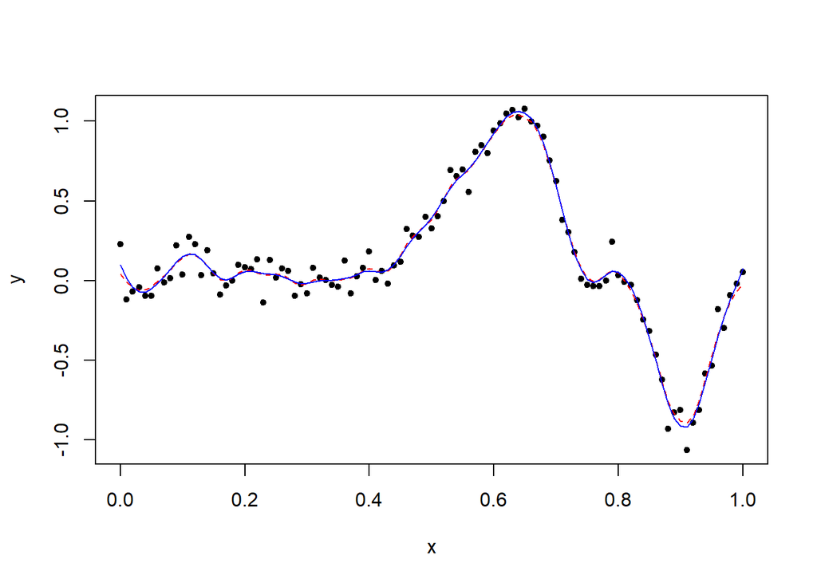

```r
matplot(x,cbind(y,nfit1$mean,ssf$y),type="pll",ylab="y", lty=c(1,2), pch=20, col=c(1,2,4))
```

One can see that two estimated regression functions do not deviate much.

Note that NW-estimator can be seen as the minimizer of the following

$$\sum_{i=1}^n (Y_i - f(x))^2K_h(X_i-x)$$

for given (fixed) $x$. That is, NW-estimator can be regarded as a localized weighted version of the least squares estimator. Here, the fact that $f(X_i) \approx f(x)$ where $X_i\approx x$ is used. In this sense, NW-estimator is also called as ``local constant estimator“. One may expand $f$ to a higher order. For example, $f(X_i) \approx f(x) + f'(x)(X_i - x)$ where $X_i\approx x$.

$$\sum_{i=1}^n (Y_i - f(x) - f'(x)(X_i - x))^2K_h(X_i-x)$$

The minimizers with respect to $f(x)$ and $f'(x)$ for given $x$ are called ``local linear estimator“. It is known that the local linear estimator has a better property especially at boundaries.

```r
library(np)
# local linear estimator, gaussian kernel & automatic selection for h
nfit2 <- npreg(y~x,regtype="ll",ckertype="gaussian")
```

```
##
Multistart 1 of 1 |
Multistart 1 of 1 |
Multistart 1 of 1 |
Multistart 1 of 1 /
Multistart 1 of 1 |
Multistart 1 of 1 |
```

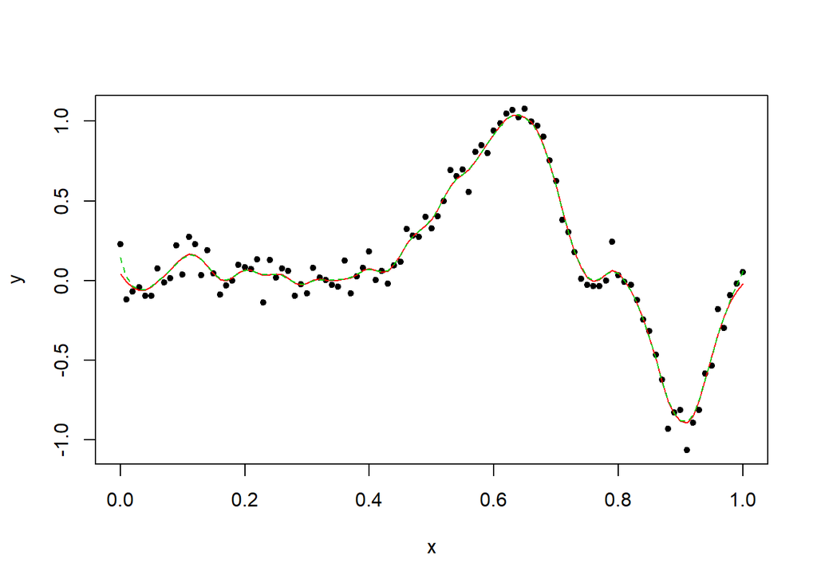

```r
matplot(x,cbind(y,nfit1$mean,nfit2$mean),type="pll",ylab="y", lty=c(2,1), pch=20, col=c(1,2,3))
```

# 6 Additive model

A generalization in the existence of multiple predictors is to consider the additive model. We do not set explicit transformations of predictors. Instead, they can be determined from data themselves in a data-drived way.

$$Y = \alpha+ f_1(X_1) + \cdots +f_d(X_d) + \epsilon$$

The linear terms have been replaced by more flexible function forms.

```r
require(mgcv)
```

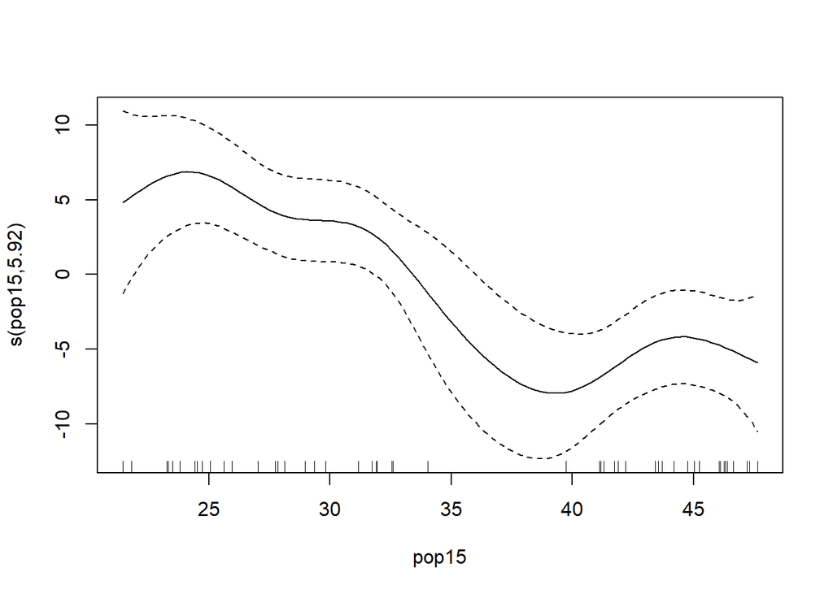

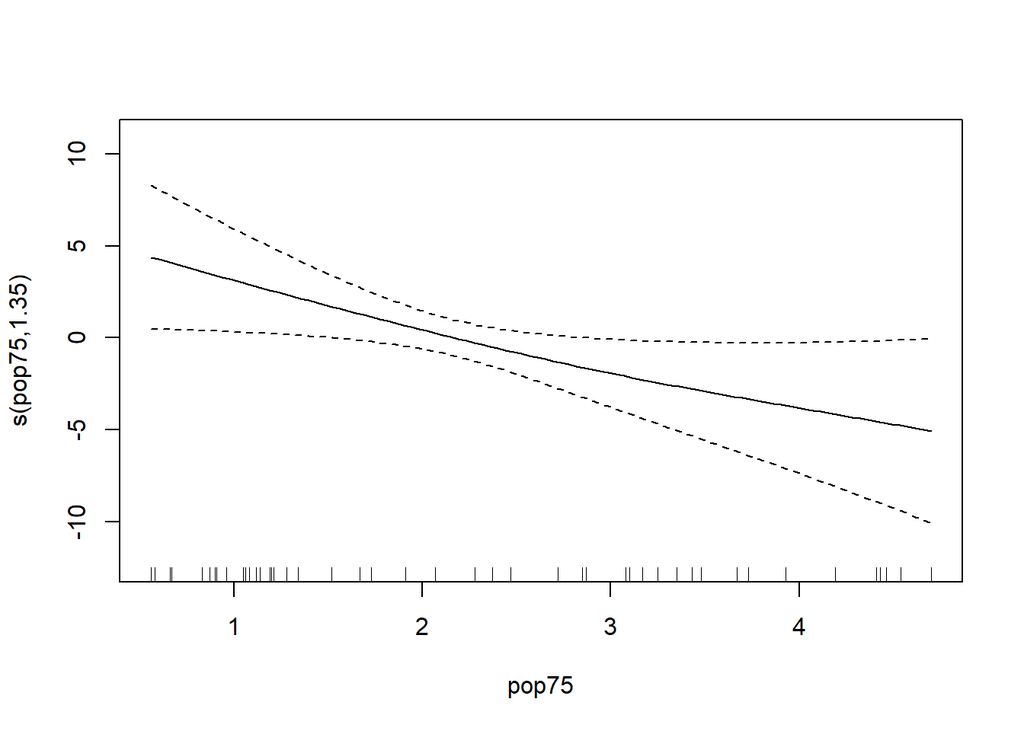

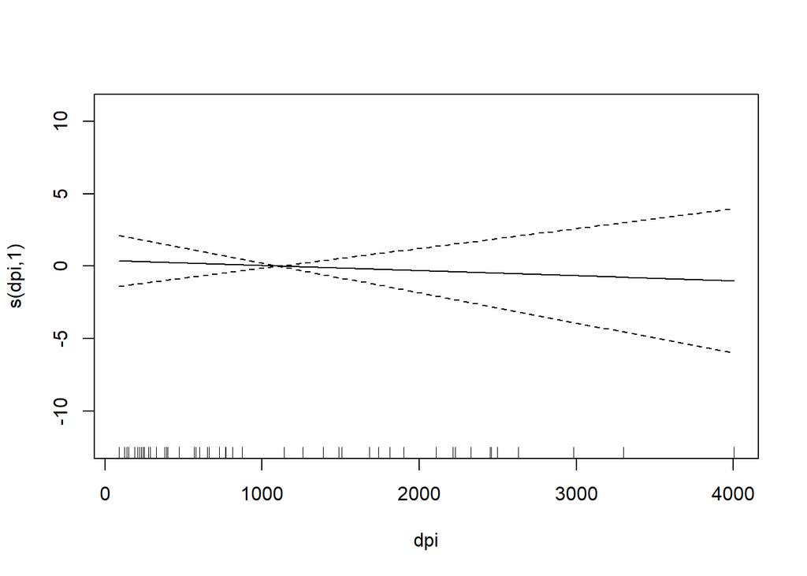

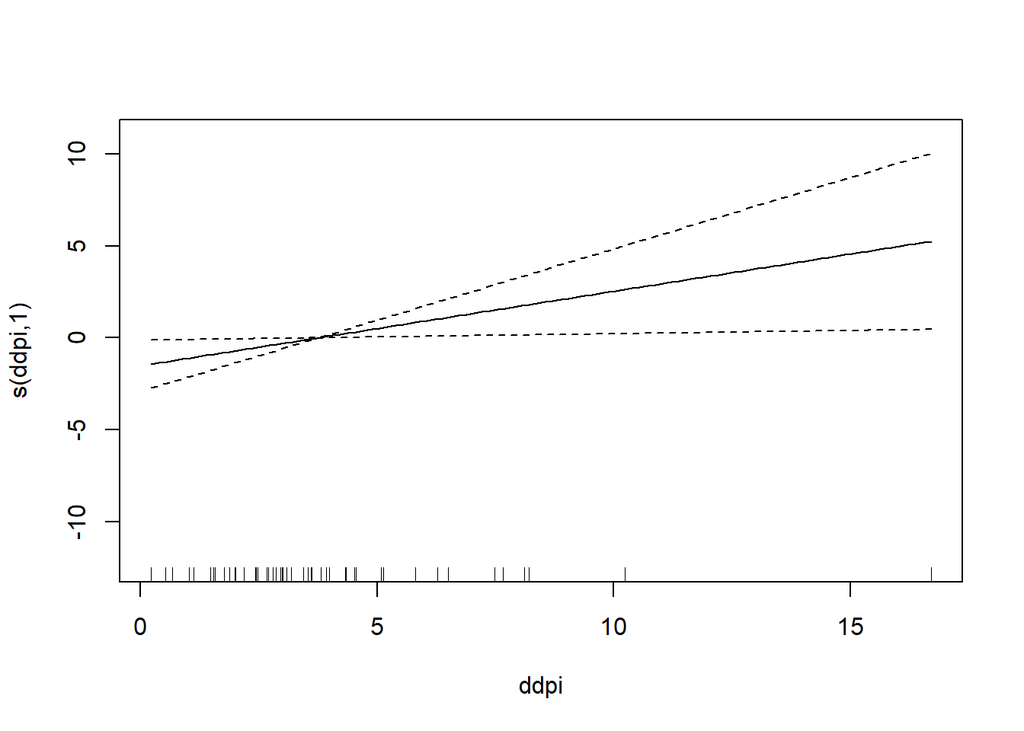

```r
gamod <- gam(sr ~ s(pop15) + s(pop75) + s(dpi) + s(ddpi), data=savings)
plot(gamod)
```

```r
summary(gamod)
```

```
##
## Family: gaussian
## Link function: identity
##
## Formula:
## sr ~ s(pop15) + s(pop75) + s(dpi) + s(ddpi)
##
## Parametric coefficients:
##             Estimate Std. Error t value Pr(>|t|)
## (Intercept)   9.6710     0.4816   20.08   <2e-16 ***
## ---
## Signif. codes:  0 '***' 0.001 '**' 0.01 '*' 0.05 '.' 0.1 ' ' 1
##
## Approximate significance of smooth terms:
##            edf Ref.df     F p-value
## s(pop15) 5.924  7.064 3.608 0.00386 **
## s(pop75) 1.350  1.623 2.811 0.06731 .
## s(dpi)   1.000  1.000 0.168 0.68404
## s(ddpi)  1.000  1.000 4.789 0.03448 *
## ---
## Signif. codes:  0 '***' 0.001 '**' 0.01 '*' 0.05 '.' 0.1 ' ' 1
##
## R-sq.(adj) =  0.422   Deviance explained = 53.2%
## GCV = 14.593  Scale est. = 11.595    n = 50
```

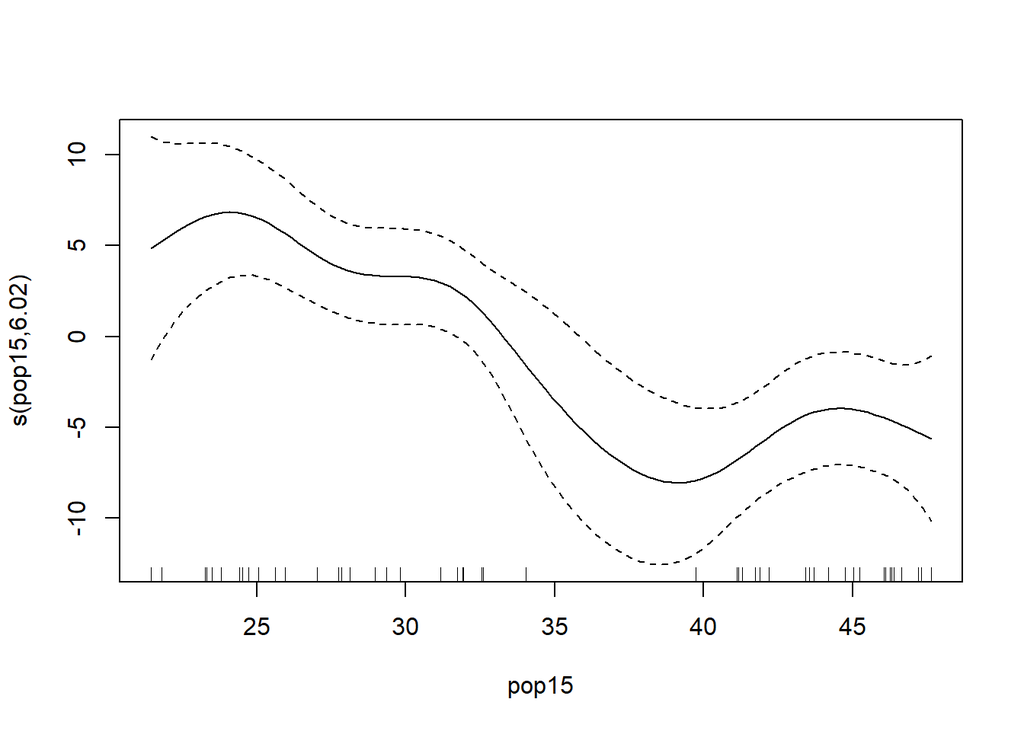

```r
gamod1 <- gam(sr ~ s(pop15) + pop75 + dpi + ddpi, data=savings)  # partially linear model
plot(gamod1)
```

```r
summary(gamod1)
```

```
##
## Family: gaussian
## Link function: identity
##
## Formula:
## sr ~ s(pop15) + pop75 + dpi + ddpi
##
## Parametric coefficients:
##               Estimate Std. Error t value Pr(>|t|)
## (Intercept) 13.7065873  2.3900799   5.735 1.12e-06 ***
## pop75       -2.2216395  1.0353105  -2.146   0.0380 *
## dpi         -0.0003672  0.0008600  -0.427   0.6717
## ddpi         0.3898901  0.1845136   2.113   0.0409 *
## ---
## Signif. codes:  0 '***' 0.001 '**' 0.01 '*' 0.05 '.' 0.1 ' ' 1
##
## Approximate significance of smooth terms:
##            edf Ref.df     F p-value
## s(pop15) 6.017  7.164 3.508 0.00444 **
## ---
## Signif. codes:  0 '***' 0.001 '**' 0.01 '*' 0.05 '.' 0.1 ' ' 1
##
## R-sq.(adj) =  0.417   Deviance explained = 52.4%
## GCV = 14.646  Scale est. = 11.712    n = 50
```

# 7 Exercise

1. # 9.1 (a), (c), (d), (e)
2. # 9.7 (a)
3. # 9.8